# Scaling smotif with smotifrs (Rust backend)

`smotifrs` is the Rust-accelerated companion to [smotif]. It exposes the same enumeration API for size-2 / size-3 / size-4 motifs but runs the inner loops on a compact CSR adjacency in Rust, and can read `nodes.parquet` / `edges.parquet` directly without materializing a `SpatialGraph` in R memory. This vignette shows how to install both packages, swap backends with a single argument, read parquet directly in Rust, and benchmark the speed/memory tradeoff at three dataset sizes. A short list of natural next steps closes the tutorial.

## 1. Installation

Both packages are needed: `smotif` for the data model and downstream analyses, `smotifrs` for the Rust kernels.

```r
# 1. Install smotif (R-only, fast)
remotes::install_github("drieslab/smotif")

# 2. Install smotifrs — RECOMMENDED: pre-built binary (no Rust toolchain)
install.packages(
  "smotifrs",
  repos = c("https://drieslab.r-universe.dev", getOption("repos"))
)

# 2a. Source install (only if you have cargo + rustc on your PATH)
# remotes::install_github("drieslab/smotifrs")
```

The R-universe path downloads a pre-compiled `.so` / `.dylib` / `.dll` matching your platform, so users who don’t want to deal with Rust never have to. Source builds remain available for power users who do.

```r
library(smotif)
library(smotifrs)
library(ggplot2)
```

## 2. Quickstart: a one-line backend swap

Anywhere you’d call `smotif::find_motifs(sg, ...)`, pass `backend = "rust"`. The output is a `Motifs` object identical in schema to the R backend — every downstream consumer (null models, gene association, niche comparison) works unchanged.

```r
ext <- system.file("extdata", "workshop_xenium", package = "smotif")
sg <- read_spatial_graph(file.path(ext, "nodes.parquet"),
                         file.path(ext, "edges.parquet"))
sg
```

```
#> <SpatialGraph>
#>   nodes: 7586  |  edges: 26304  |  build: read_spatial_graph
#>   samples (1): workshop_xenium
#>   regions (3): niche_1=4750, niche_3=1706, niche_2=1130
#>   cell types (9, top 5): cluster_4=1610, cluster_2=1390, cluster_1=1045, cluster_3=957, cluster_6=753
```

```r
m_ig <- find_motifs(sg, size = 3L, backend = "igraph")
m_rs <- find_motifs(sg, size = 3L, backend = "rust")

# Bit-for-bit parity on the catalog.
identical(
  m_ig$catalog[order(motif_id), .(motif_id, count)],
  m_rs$catalog[order(motif_id), .(motif_id, count)]
)
```

```
#> [1] TRUE
```

**What’s happening under the hood.** `smotif`’s pure-R backend builds an igraph object and runs `data.table` joins to enumerate triangles and wedges. `smotifrs` instead constructs a compact compressed-sparse-row adjacency in Rust (sorted neighbor lists per vertex), then runs:

- **size 2** — vectorized over edges with packed integer color keys.
- **size 3 closed** — sorted-merge triangle intersection: for every edge `u-v` with `u < v`, walk `N(u) ∩ N(v)` keeping only `w > v`.
- **size 3 open** — for each center, every unordered pair of neighbors that is *not itself* an edge (one O(1) hash lookup against an `ahash` packed-edge set).
- **size 4** — extend every connected 3-subgraph by a fourth vertex, dedupe with `u128`-packed keys, classify by `(n_edges, sorted degrees)` into one of `{path, claw, cycle, paw, diamond, K4}`.

Canonical motif labels (sort vertices by `(degree-in-motif, color)`) match the R kernel byte-for-byte, which is why the parity check passes.

## 3. Direct parquet I/O — for million-cell datasets

For graphs that don’t fit comfortably in R memory, skip the `SpatialGraph` round-trip. `find_motifs_from_parquet()` reads nodes.parquet and edges.parquet directly via `arrow-rs`, builds the CSR in Rust, and returns the motif catalog without ever allocating the bulk node/edge data on R’s heap.

```r
m_direct <- find_motifs_from_parquet(
  file.path(ext, "nodes.parquet"),
  file.path(ext, "edges.parquet"),
  size = 3L
)
identical(
  m_direct$catalog[order(motif_id), count],
  m_rs$catalog[order(motif_id), count]
)
```

```
#> [1] TRUE
```

The motif catalog and incidence tables are small (one row per motif type and one per vertex-instance respectively) so they round-trip back to R cheaply. The expensive 1M+ row edges table stays in Rust.

## 4. Benchmark: three synthetic kNN graphs

```r
make_synthetic <- function(n, k = 6L, seed = 1L) {
  set.seed(seed)
  coords <- cbind(x = stats::runif(n, 0, 1000),
                  y = stats::runif(n, 0, 1000))
  types <- sample(c("T", "B", "M", "E", "X"), n, replace = TRUE)
  build_spatial_graph(
    coords, types, "synth",
    cell_id = paste0("c", seq_len(n)),
    method = "knn", k = k
  )
}

peak_mb_from_gc <- function(g) {
  # Robust across R versions: locate the "max used" column and read
  # the Mb counterpart immediately after it.
  i <- which(colnames(g) == "max used")
  if (!length(i) || ncol(g) < i + 1L) return(NA_real_)
  sum(g[, i + 1L])
}

bench_one <- function(label, fn) {
  invisible(gc(reset = TRUE, full = TRUE))
  t1 <- Sys.time()
  # Keep the result alive until t2 so its allocation is captured by gc().
  result_holder <- fn()
  t2 <- Sys.time()
  g <- gc(verbose = FALSE)
  rm(result_holder)
  data.frame(
    label     = label,
    elapsed   = as.numeric(difftime(t2, t1, units = "s")),
    r_peak_mb = peak_mb_from_gc(g)
  )
}
```

```r
sizes <- c(small = 2500L, medium = 10000L, large = 30000L)
out <- list()
for (sz_name in names(sizes)) {
  n <- sizes[[sz_name]]
  message("building synthetic graph: ", n, " cells")
  sg_n <- make_synthetic(n)
  for (motif_size in c(3L, 4L)) {
    out[[length(out) + 1L]] <- transform(
      bench_one(
        sprintf("%s/N=%d/size=%d/igraph", sz_name, n, motif_size),
        function() find_motifs(sg_n, size = motif_size, backend = "igraph")
      ),
      backend = "igraph", N = n, motif_size = motif_size, sz_name = sz_name
    )
    out[[length(out) + 1L]] <- transform(
      bench_one(
        sprintf("%s/N=%d/size=%d/rust", sz_name, n, motif_size),
        function() find_motifs(sg_n, size = motif_size, backend = "rust")
      ),
      backend = "rust", N = n, motif_size = motif_size, sz_name = sz_name
    )
  }
}
```

```
#> building synthetic graph: 2500 cells
#> building synthetic graph: 10000 cells
#> building synthetic graph: 30000 cells
```

```r
bench <- do.call(rbind, out)
bench$sz_name <- factor(bench$sz_name, levels = names(sizes))
```

```r
data.table::setDT(bench)
bench[, .(label, elapsed_s = round(elapsed, 2),
          r_peak_mb = round(r_peak_mb, 1))]
```

```
#>                            label elapsed_s r_peak_mb
#>                           <char>     <num>     <num>
#>  1:   small/N=2500/size=3/igraph      0.11     210.3
#>  2:     small/N=2500/size=3/rust      0.08     159.4
#>  3:   small/N=2500/size=4/igraph      1.52     368.3
#>  4:     small/N=2500/size=4/rust      0.52     230.1
#>  5: medium/N=10000/size=3/igraph      0.39     335.2
#>  6:   medium/N=10000/size=3/rust      0.37     202.3
#>  7: medium/N=10000/size=4/igraph      5.25    1004.1
#>  8:   medium/N=10000/size=4/rust      2.27     477.7
#>  9:  large/N=30000/size=3/igraph      1.17     569.7
#> 10:    large/N=30000/size=3/rust      1.17     328.9
#> 11:  large/N=30000/size=4/igraph     16.14    2726.5
#> 12:    large/N=30000/size=4/rust      7.18    1165.8
```

### 4a. Speedup vs dataset size

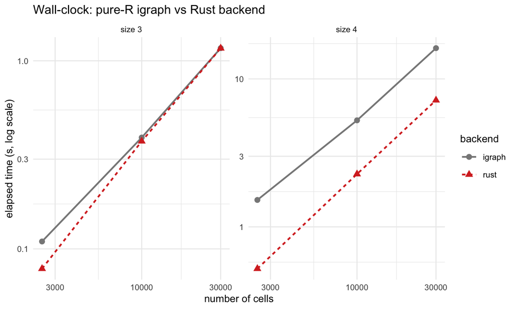

```r
ggplot(bench,
       aes(x = N, y = elapsed, color = backend, linetype = backend,
           shape = backend)) +
  geom_line(linewidth = 0.8) +
  geom_point(size = 2.4) +
  facet_wrap(~ paste("size", motif_size), scales = "free_y") +
  scale_x_log10() +
  scale_y_log10() +
  scale_color_manual(values = c(igraph = "#888888", rust = "#d73027")) +
  labs(x = "number of cells", y = "elapsed time (s, log scale)",
       title = "Wall-clock: pure-R igraph vs Rust backend") +
  theme_minimal(base_size = 10)
```

```r
sp <- data.table::dcast(bench,
                        sz_name + N + motif_size ~ backend,
                        value.var = "elapsed")
sp[, speedup := round(igraph / rust, 2)]
sp[, .(sz_name, N, motif_size,
       igraph_s = round(igraph, 2),
       rust_s   = round(rust, 2),
       speedup)]
```

```
#> Key: <sz_name, N, motif_size>
#>    sz_name     N motif_size igraph_s rust_s speedup
#>     <fctr> <int>      <int>    <num>  <num>   <num>
#> 1:   small  2500          3     0.11   0.08    1.40
#> 2:   small  2500          4     1.52   0.52    2.91
#> 3:  medium 10000          3     0.39   0.37    1.05
#> 4:  medium 10000          4     5.25   2.27    2.31
#> 5:   large 30000          3     1.17   1.17    1.00
#> 6:   large 30000          4    16.14   7.18    2.25
```

### 4b. R-side memory peak

Pure R routes pass through `data.table` joins that materialize every candidate motif as a row before deduplication; the Rust backend keeps the graph in its own heap and only ships the final catalog/incidence back to R. The result is a roughly N-proportional gap in R-side working set.

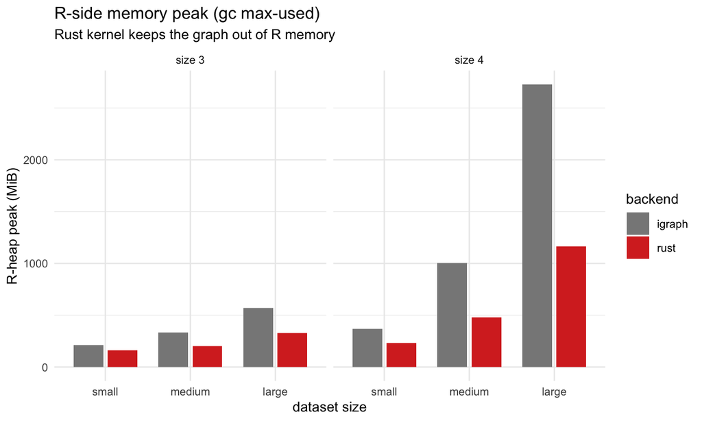

```r
ggplot(bench,
       aes(x = sz_name, y = r_peak_mb, fill = backend)) +
  geom_col(position = position_dodge(width = 0.8), width = 0.7) +
  facet_wrap(~ paste("size", motif_size)) +
  scale_fill_manual(values = c(igraph = "#888888", rust = "#d73027")) +
  labs(x = "dataset size", y = "R-heap peak (MiB)",
       title = "R-side memory peak (gc max-used)",
       subtitle = "Rust kernel keeps the graph out of R memory") +
  theme_minimal(base_size = 10)
```

The reported number is the maximum R heap used during the call (read from `gc()`’s `"max used"` column). It excludes whatever Rust’s own allocator reserves for its CSR — that’s a separate working set, far smaller than the equivalent `data.table` representation in R, but not visible to R’s `gc()`.

## 5. Where this matters in practice

- **Hot inner loop in repeated analyses.** Permutation-based enrichment (`smotif::test_motif_enrichment`) doesn’t currently re-enumerate motifs (it just relabels), but if you script your own motif-recount-per-permutation, swapping the backend cuts wall time.
- **Parquet pipelines from upstream tools.** If you’re already writing `nodes.parquet` and `edges.parquet` from a Python or Giotto pipeline, `find_motifs_from_parquet()` lets you skip the R-side ingest entirely. Useful when those files exist on object storage and you’d rather not pull them through R’s Arrow bindings.
- **CI / batch jobs at scale.** The 30k benchmark runs in seconds with the Rust backend on a single core; parallelism (next section) makes ≥1M-cell jobs feasible inside R.

## 6. Future improvements

A few natural next steps, in rough order of payoff for the size of slides we expect to see:

1. **Parallel enumeration** — the current Rust backend is single-threaded. The size-3-closed and size-3-open kernels are embarrassingly parallel over the outer vertex loop; wiring up `rayon::into_par_iter` is a one-liner per kernel and should give 4–8× on a typical laptop CPU.
2. **Streaming size-4 incidence to disk.** Catalogs stay small even at 1M cells, but the per-instance incidence table can balloon into the hundreds of millions of rows. An `incidence_path = ...` argument that streams parquet output (one batch per topology class) keeps R’s memory flat and makes downstream queries a `arrow::open_dataset()` call.
3. **Size 5+ motifs via ESU + color-coding.** The exhaustive 3-subgraph extension we use for size 4 doesn’t generalize cleanly; Wernicke’s ESU enumerator with color-coding samples a controlled fraction of the search space and is the standard approach for k≥5.
4. **Per-sample meta-analysis in Rust.** `associate_genes(pooling = "per_sample")` loops over samples in R today; pushing the Wilcoxon rank-sum down to Rust (with sample-stratified rank arrays) avoids the per-call extendr overhead.
5. **Exact canonical labeling for size 4.** Today’s `(degree, color)` sort is approximate (collides on certain colored cycles). Bliss or a hand-coded Schreier-Sims tailored to size 4 would close the gap without the cost of a full nauty-style canonicalization.
6. **GPU enumeration.** For very large slides, a CUDA / wgpu kernel for triangle counting + per-pair color aggregation would push throughput by another order of magnitude — useful once whole-organ atlases (millions of cells per slide, dozens of slides) become routine.

The first two are the most concrete wins; everything below is research-tier work whose payoff depends on what biology people actually want to ask of these datasets.